# Homework 6

Ryan Hensley

2023-10-20

**Copyright Kaitlyn Hoffmann, All rights reserved. Not for resale, distribution, or posting to external sites for all content provided.**

# Cluster Analysis

Data taken from: https://www.kaggle.com/datasets/arjunbhasin2013/ccdata

## Question 1: Create a data frame loaded from creditcarddata.csv

```r
creditcard = read.csv("creditcarddata.csv")
```

## Question 2: Display the first 10 rows from the data frame called creditcard

```r
head(creditcard,10)
```

```
##    CUST_ID    BALANCE BALANCE_FREQUENCY PURCHASES ONEOFF_PURCHASES
## 1   C10001   40.90075          0.818182     95.40             0.00
## 2   C10002 3202.46742          0.909091      0.00             0.00
## 3   C10003 2495.14886          1.000000    773.17           773.17
## 4   C10004 1666.67054          0.636364   1499.00          1499.00
## 5   C10005  817.71434          1.000000     16.00            16.00
## 6   C10006 1809.82875          1.000000   1333.28             0.00
## 7   C10007  627.26081          1.000000   7091.01          6402.63
## 8   C10008 1823.65274          1.000000    436.20             0.00
## 9   C10009 1014.92647          1.000000    861.49           661.49
## 10  C10010  152.22598          0.545455   1281.60          1281.60
##    INSTALLMENTS_PURCHASES CASH_ADVANCE PURCHASES_FREQUENCY
## 1                   95.40        0.000            0.166667
## 2                    0.00     6442.945            0.000000
## 3                    0.00        0.000            1.000000
```

[output cut: 40 more lines]

## Question 3: Create a new data frame creditcardNUM that will remove the non-numeric data from creditcard so we can procede with the K-Means analysis

```r
creditcardNUM = creditcard
creditcardNUM$CUST_ID = NULL
```

## Install factoextra and run the library

- select the line below and click on Run selected line or Ctrl+Enter (Cmd+Enter)
- having install.packages code within a chunk can cause issues when knitting to HTML

```r
library(factoextra)
```

## Visualize the Elbow Method and Silhouette Method, where the Elbow is that is the optimal number of K

- fviz_nbclust(creditcardNUM, kmeans, method = “wss”)
- fviz_nbclust(creditcardNUM, kmeans, method = “silhouette”)

**Note this code may take a few moments to run**

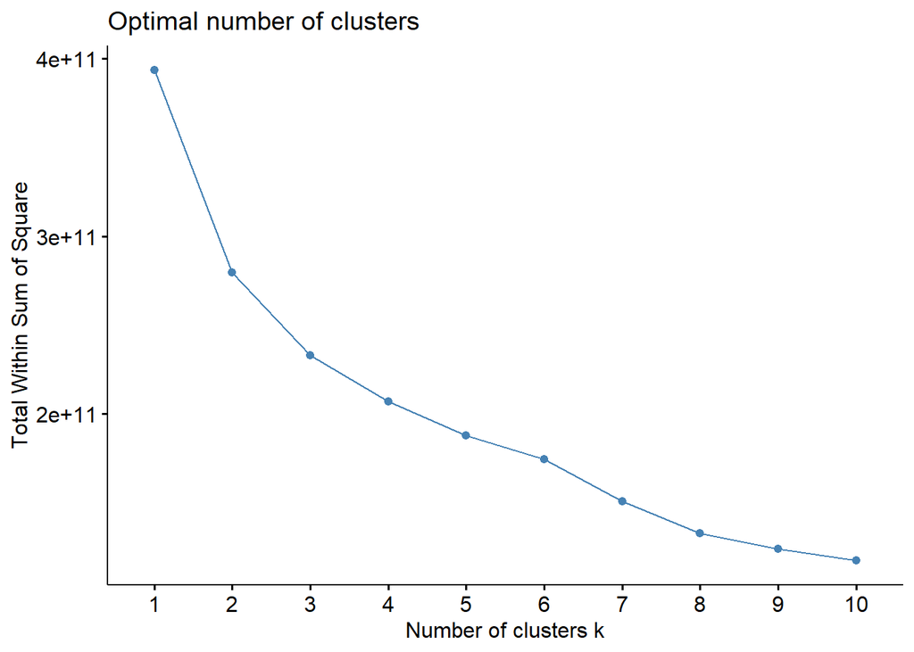

```r
par(mfrow=c(1,2))
fviz_nbclust(creditcardNUM, kmeans, method = "wss")
```

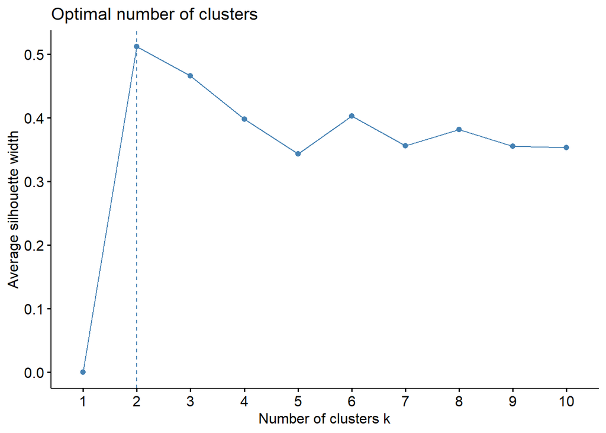

```r
fviz_nbclust(creditcardNUM, kmeans, method = "silhouette")
```

## Question 4: Set the seed and build a model for k=1 and k=2 using kmeans

- Run K-Means for 1 cluster (k=1) and call the model km1
- Run K-Means for 2 clusters (k=2) and call the model km2
- Do not display the results, you will do that in the next few chunks

```r
set.seed(123)
#km1
km1 = kmeans(creditcardNUM,1)

#km2
km2 = kmeans(creditcardNUM,2)
```

## Question 5: Display the results for km1

```r
km1
```

```
## K-means clustering with 1 clusters of sizes 8950
##
## Cluster means:
##    BALANCE BALANCE_FREQUENCY PURCHASES ONEOFF_PURCHASES INSTALLMENTS_PURCHASES
## 1 1564.475         0.8772707  1003.205         592.4374               411.0676
##   CASH_ADVANCE PURCHASES_FREQUENCY ONEOFF_PURCHASES_FREQUENCY
## 1     978.8711           0.4903505                  0.2024577
##   PURCHASES_INSTALLMENTS_FREQUENCY CASH_ADVANCE_FREQUENCY CASH_ADVANCE_TRX
## 1                        0.3644373              0.1351442         3.248827
##   PURCHASES_TRX CREDIT_LIMIT PAYMENTS MINIMUM_PAYMENTS PRC_FULL_PAYMENT
## 1      14.70983     4493.947 1733.144         833.9835        0.1537146
##     TENURE
## 1 11.51732
##
## Clustering vector:
```

[output cut: 251 more lines]

## Question 6: Display the results for km2

```r
km2
```

```
## K-means clustering with 2 clusters of sizes 1921, 7029
##
## Cluster means:
##     BALANCE BALANCE_FREQUENCY PURCHASES ONEOFF_PURCHASES INSTALLMENTS_PURCHASES
## 1 3838.1596         0.9402500 2366.1378        1552.8890               813.6329
## 2  943.0851         0.8600587  630.7203         329.9495               301.0480
##   CASH_ADVANCE PURCHASES_FREQUENCY ONEOFF_PURCHASES_FREQUENCY
## 1    2594.4340           0.5576099                  0.3461490
## 2     537.3437           0.4719688                  0.1631874
##   PURCHASES_INSTALLMENTS_FREQUENCY CASH_ADVANCE_FREQUENCY CASH_ADVANCE_TRX
## 1                        0.4055694              0.2273061         6.562207
## 2                        0.3531961              0.1099567         2.343292
##   PURCHASES_TRX CREDIT_LIMIT PAYMENTS MINIMUM_PAYMENTS PRC_FULL_PAYMENT
## 1      28.02499     9825.874 4292.149        1753.9329        0.1494403
## 2      11.07085     3036.751 1033.777         582.5646        0.1548828
```

[output cut: 256 more lines]

## Question 7: Answer the following within the chunk as a comment:

- What are the cluster sizes for km2?
- What is the average minimum payment for cluster2 compared to cluster1 for km2?
- What is the average balance for cluster2 compared to cluster1 for km2?
- What is the total sum of squares for km1?
- What is the within sum of squares for 2 clusters (km2)?
- What is the total sum of squares for 2 clusters (km2)?
- What is percent reduction from km1 to km2?

```r
#---------------------------------------
#What are the cluster sizes for km2?
#Cluster 1: 1921
#Cluster 2: 7029
#---------------------------------------
#What is the average minimum payment for cluster2 compared to cluster1 for km2?
#Cluster 1: 1753.9329
#Cluster 2: 582.5646
1753.9329 - 582.5646
```

```
## [1] 1171.368
```

```r
#Difference: 1171.368
#---------------------------------------
#What is the average balance for cluster2 compared to cluster1 for km2?
#Cluster 1: 3838.1596
#Cluster 2: 943.0851
3838.1596-943.0851
```

```
## [1] 2895.074
```

```r
#Difference: 2895.074
#---------------------------------------
#What is the total sum of squares for km1?
#km1 total sum of squares: 393306778023
#---------------------------------------
#---------------------------------------
#What is the within sum of squares for 2 clusters (km2)?
# 204726166357  74728388893
#---------------------------------------
#What is the total sum of squares for 2 clusters (km2)?
204726166357 +  74728388893
```

```
## [1] 279454555250
```

```r
# 279454555250
#---------------------------------------
#What is percent reduction from km1 to km2?
# 28.9% reduction
#---------------------------------------
```

## Question 8: Add the cluster vector from km2 back to creditcard as column/variable cluster2

```r
creditcard$cluster2 = km2$cluster
```

## Question 9: Displays creditcard, ordered by cluster2

- dataframe[order(dataframe$column), ]

```r
creditcard[order(creditcard$cluster2), ]
```

```
##      CUST_ID      BALANCE BALANCE_FREQUENCY PURCHASES ONEOFF_PURCHASES
## 2     C10002  3202.467416          0.909091      0.00             0.00
## 7     C10007   627.260806          1.000000   7091.01          6402.63
## 10    C10010   152.225975          0.545455   1281.60          1281.60
## 16    C10016  6886.213231          1.000000   1611.70             0.00
## 19    C10019  1989.072228          1.000000    504.35           166.00
## 22    C10022  6369.531318          1.000000   6359.95          5910.04
## 24    C10024  3800.151377          0.818182   4248.35          3454.56
## 29    C10029  7152.864372          1.000000    387.05           204.55
## 31    C10031 12136.219960          1.000000   3038.01          1013.20
## 33    C10033  6732.823064          1.000000    324.95           324.95
## 35    C10035  3517.101616          0.727273    547.28             0.00
## 37    C10037  7427.076941          1.000000      0.00             0.00
## 39    C10039  6269.418144          1.000000    204.00           204.00
## 40    C10040  1411.602230          0.454545    963.24           963.24
```

[output cut: 26306 more lines]

## Question 10: Conceptually, take everything you have learned up to this point and look at the data to provide a brief thought on what you can do to further analyze this data now that there are 2 clusters. What can you do to compare or contrast the clusters? Just provide one to two examples (there are many possibilities).

```r
#Commented Response:
# The data in km2 is reduced from 100 percent down to 71.1% of the data, allowing for data that is more closely related to be analyzed. For example, analyzing payments that are closer to each other or balances that are closer to each other. The idea of clustering is to consolidate data that is close to each other. Hypothethicaly, as we increase the number of clusters the data in each cluster will be closer and closer, allowing outliers to not affect the data as much.
```

Take the results for further analysis and profiling

### Knit to HTML

**Copyright Kaitlyn Hoffmann, All rights reserved. Not for resale, distribution, or posting to external sites for all content provided.**